# Changing Cupcake Parameters

Szi Kay Leung

2021-01-11

# Aims

**To evaluate consequences of reducing cupcake parameters (coverage identity) from 99% (default) to 95% on whole transcriptome**  
- Number of isoforms and genes from SQANTI filtered report using the two different praameters  
- Explore the additional isoforms that are retained from 95% –> lower FL count in general?  
- Visually check additional isoforms

**Previously using ERCC**, demonstrated with ERCC that cupcake’s coverage default parameter at 99% is too stringent, with 20 lowly-expressed ERCCs discarded. **therefore**, reran demux pipeline on merged whole transcriptome data (n = 12) but using a lower coverage threshold (95%).

# Method

Checking the number of transcripts throughout pipeline from alignment with mouse genome (Minimap2):  
1. Cupcake collapse (coverage identity at default threshold - 99% or at reduced threshold - 95%)  
2. Cupcake filter  
3. SQANTI characterisation  
4. SQANTI filtering  
5. TAMA filtering

Two analysis were done in parallel with the only difference in the cupcake coverage identity parameter (at cupcake collapse).

## Pipeline

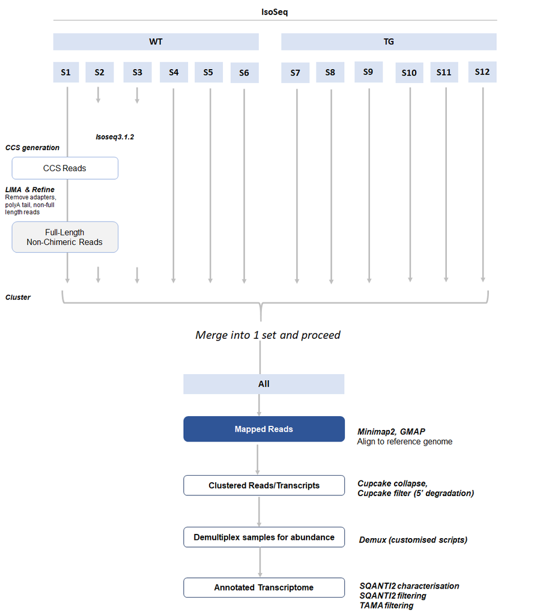

Pipeline for analysis

```r
# function to read in the individual files
read_inputfile <- function(path_inputfile, sqanti_gtf, file_option){
  #cat("processing", path_inputfile,"\n")

  if (file_option == "cupcake"){
    df <-  read.table(path_inputfile, as.is = T, sep = "\t", header = T)%>%
      mutate(cluster = paste0("PB.",word(.$pbid, c(2), sep = fixed("."))))
  } else if (file_option == "sqanti_discard"){
    df <-  read.table(path_inputfile, as.is = T, sep = ",", header = T) %>%
      mutate(cluster = paste0("PB.",word(.$filtered_isoform, c(2), sep = fixed("."))))
  } else if (file_option == "tama_discard"){
    df <-  read.table(path_inputfile, as.is = T) %>%
      mutate(id = paste0("PB.",word(.$V4, c(2), sep = fixed(";"))))
  } else if (file_option == "ignore"){
    df <- read.table(path_inputfile, as.is = T, sep = "\t")
  } else if (file_option == "sqanti"){
    df <- read.table(path_inputfile, as.is = T, sep = "\t", header = TRUE) %>%
      mutate(id = paste0(ifelse(structural_category != "fusion",
                         word(associated_gene,c(1), sep ="_"),associated_gene),
                         "/",associated_transcript,"/",structural_category,"/", chrom, "/", length))
    # Create a new attribute called "novelGene"
    df$novelGene <- "Annotated Genes"
    df[grep("novelGene", df$associated_gene), "novelGene"] <- "Novel Genes"
    df$novelGene = factor(df$novelGene, levels = c("Novel Genes","Annotated Genes"),ordered=TRUE)

    df <- read_merge_gtf(sqanti_gtf,df)
  } else {
    print("Check arguments")
  }

  return(df)
}

# assume the files are the same in the two analysis, only difference is the directory name
all_read <- function(root_dir){
  all <- list(
  read_inputfile(paste0(root_dir,"TOFU/WholeIsoSeq.ignored_ids.txt"),"NA", "ignore"),                  # cupcake collapse ignored isoforms
  read_inputfile(paste0(root_dir,"TOFU/WholeIsoSeq.collapsed.abundance.txt"),"NA", "cupcake"),   # cupcake collapse
  read_inputfile(paste0(root_dir,"TOFU/WholeIsoSeq.collapsed.filtered.abundance.txt"),"NA","cupcake"),  # cupcake filter
  read_inputfile(paste0(root_dir,"SQANTI/WholeIsoSeq.collapsed.filtered_classification.txt"),
                 paste0(root_dir,"SQANTI/WholeIsoSeq.collapsed.filtered_corrected.gtf"), "sqanti"), # sqanti characterisation
  read_inputfile(paste0(root_dir,"SQANTI/WholeIsoSeq.collapsed.filtered_classification.filtered_lite_classification.txt"),
                 paste0(root_dir,"SQANTI/WholeIsoSeq.collapsed.filtered_classification.filtered_lite.gtf"), "sqanti"), # sqanti filter
  read_inputfile(paste0(root_dir,"SQANTI/WholeIsoSeq.collapsed.filtered_classification.filtered_lite_reasons.txt"),"NA","sqanti_discard"), # sqanti filtering reason
  read_inputfile(paste0(root_dir,"SQANTI_TAMA_FILTER/WholeIsoSeq.collapsed_sqantitamafiltered.classification.txt"),
                 paste0(root_dir,"SQANTI_TAMA_FILTER/WholeIsoSeq.collapsed_sqantitamafiltered.classification.gtf"), "sqanti"), # sqanti after tama filtering
  read_inputfile(paste0(root_dir,"SQANTI_TAMA_FILTER/tama_retained_pbid.txt"),"NA", "ignore"), # tama retained
  read_inputfile(paste0(root_dir,"TAMA_Filter/WholeIsoSeq_discarded.txt"),"NA", "tama_discard") # tama ignore
)
  names(all) <- c("cup_coll_ign","cup_coll","cup_fil","sq","sq_fil","sq_ign","sq_tama","sq_tama_id","sq_tama_discard")
  return(all)
}

# coverage threshold at 99%
c99_dir <- "/gpfs/mrc0/projects/Research_Project-MRC148213/sl693/IsoSeq/Whole_Transcriptome/All_Merged/DEMUX_CUSTOM/"
c99 <- all_read(c99_dir)

# coverage threshold at 95%
c95_dir <- "/gpfs/mrc0/projects/Research_Project-MRC148213/sl693/IsoSeq/Whole_Transcriptome/All_Merged/DEMUX_CUSTOM_ADJUST/"
c95 <- all_read(c95_dir)
```

# Main Results

### Cupcake Collapse - Discarded

As expected, all the transcripts discarded in 95% coverage dataset are within the 99% coverage dataset

#### Numbers

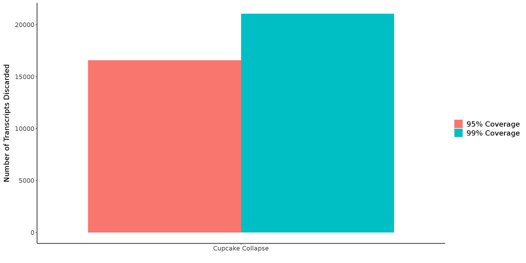

```r
num <- bind_rows(sapply(c99, nrow) %>% melt() %>% rownames_to_column(., var = "fileinput") %>% mutate(type = "coverage_99"),
          sapply(c95, nrow) %>% melt() %>% rownames_to_column(., var = "fileinput") %>% mutate(type = "coverage_95"))

num %>% filter(fileinput == "cup_coll_ign") %>%
  ggplot(., aes(x = fileinput, y = value, fill = type)) + geom_bar(stat = "identity", position = position_dodge()) +
  labs(y = "Number of Transcripts Discarded", x = "") + mytheme +
  scale_x_discrete(labels=c("Cupcake Collapse")) +
  scale_fill_discrete(labels = c("95% Coverage","99% Coverage"), name = "")
```

#### Overlap

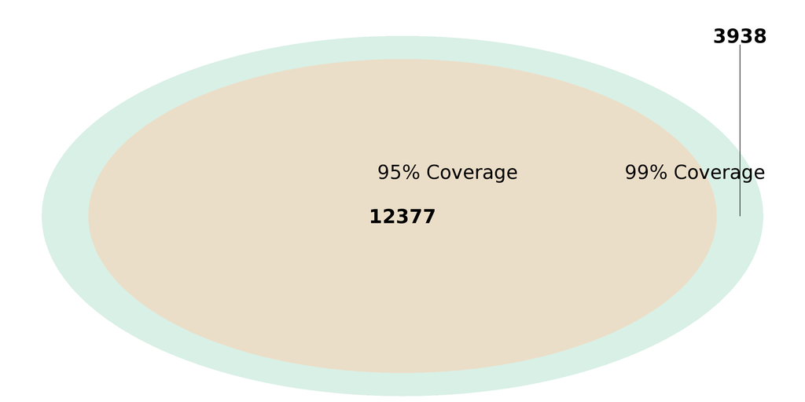

```r
grid.draw(venn_diagram_plot_twocircles(c99$cup_coll_ign$V1,c95$cup_coll_ign$V1,"99% Coverage","95% Coverage"))
```

### Number of unique isoforms

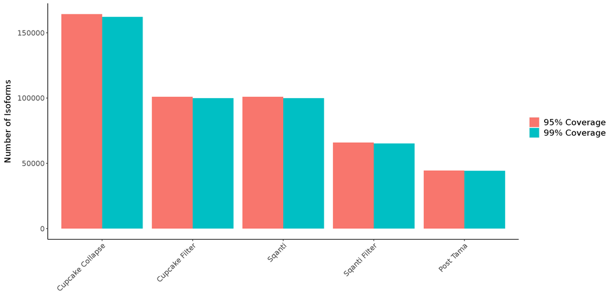

```r
'%ni%' <- Negate('%in%')
df <- num[num$fileinput %ni% c("cup_coll_ign","sq_ign","sq_tama_discard","sq_tama_id"),]
ggplot(df, aes(x = fileinput, y = value, fill = type)) +
  geom_bar(stat = "identity", position = position_dodge()) +
  labs(y = "Number of Isoforms", x = "") + mytheme +
  scale_x_discrete(labels=c("Cupcake Collapse","Cupcake Filter","Sqanti","Sqanti Filter","Post Tama")) +
  scale_fill_discrete(labels = c("95% Coverage","99% Coverage"), name = "") +
  theme(axis.text.x = element_text(angle = 45, hjust=1))
```

# Filters

### Cupcake Filter

Cupcake filter removes any 5’ degraded products. Interestingly, while cupcake collapse generates almost idental dataset between the two analyses, there is very low overlap between cupcake filter.

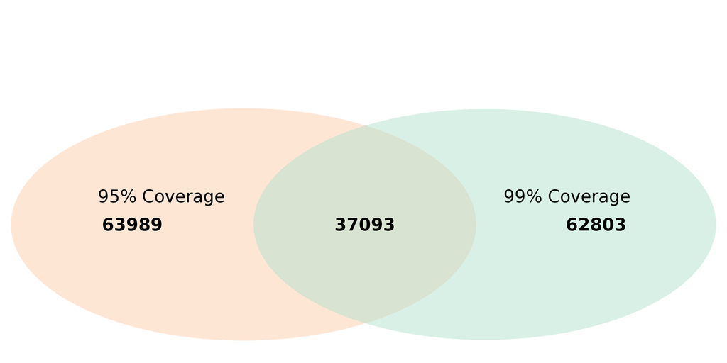

```r
grid.draw(venn_diagram_plot_twocircles(c99$cup_fil$pbid,c95$cup_fil$pbid,"99% Coverage","95% Coverage"))
```

### Sqanti

#### Overlap

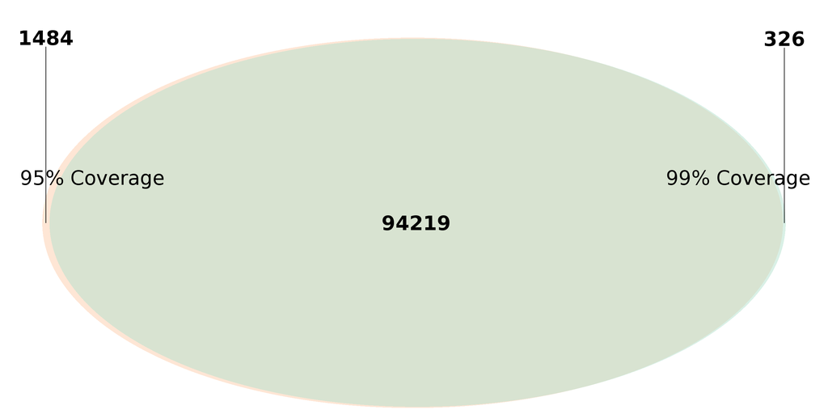

```r
grid.draw(venn_diagram_plot_twocircles(c99$sq$gtf_coordinates,c95$sq$gtf_coordinates,"99% Coverage","95% Coverage"))
```

#### 99% Coverage

##### Unique Isoforms

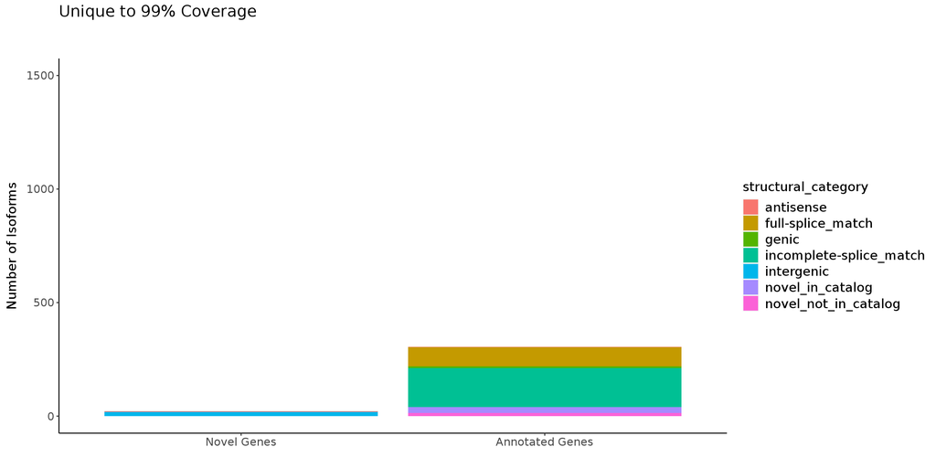

```r
# in 99% default but not in 95%
c99$sq %>% filter(gtf_coordinates %in% setdiff(c99$sq$gtf_coordinates,c95$sq$gtf_coordinates)) %>%
  group_by(structural_category,novelGene) %>% tally() %>%
  ggplot(., aes(fill = structural_category, y = n, x = novelGene)) + geom_bar(stat = "identity") +
  mytheme + labs(y = "Number of Isoforms", x = "", title = "Unique to 99% Coverage\n\n") + ylim(0,1500)
```

##### Genes - Num of Unique Isoforms

```r
datatable(c99$sq %>% filter(gtf_coordinates %in% setdiff(c99$sq$gtf_coordinates,c95$sq$gtf_coordinates)) %>% group_by(associated_gene) %>% tally() %>% arrange(desc(n)),  caption = "Genes with isoforms present in 99% but not in 95% coverage")
```

|  | associated_gene | n |
| --- | --- | --- |
| 1 | Cntnap5a | 6 |
| 2 | mt-Rnr2 | 6 |
| 3 | Ncam1 | 6 |
| 4 | Dcc | 4 |
| 5 | Tnr | 4 |
| 6 | Unc5d | 4 |
| 7 | D430041D05Rik | 3 |
| 8 | Ide | 3 |
| 9 | Kcnq5 | 3 |
| 10 | Lsamp | 3 |

[output cut: 266 more lines]

##### Isoforms unique to coverage-99% dataset

**Figure 1: Isoforms detected in SQANTI annotation using different Cupcake collapse parameters**  
UCSC genome browser track of isoforms annotated to **a)** *Dcc* gene and **b)** *Ctnap5a* gene from *SQANTI* annotation (pre-filtering). The same dataset was collapsed with *Cupcake* using either using coverage threshold of 99% (default) or 95% (determined experimentally using ERCCs).

Isoforms that were unique to the coverage-99% dataset are short-monoexonic isoforms at the 5’ and 3’ end (boxed blue).

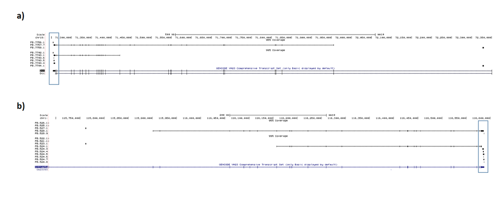

#### 95% Coverage

##### Unique Isoforms

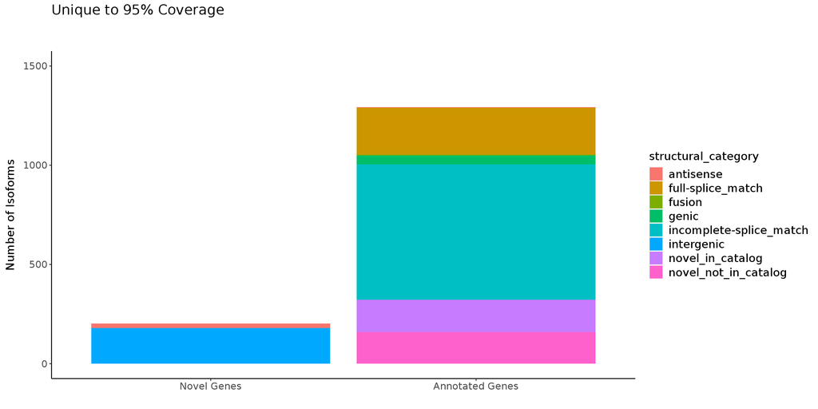

```r
# in 95% but not in 99%
c95$sq %>% filter(gtf_coordinates %in% setdiff(c95$sq$gtf_coordinates,c99$sq$gtf_coordinates)) %>%
  group_by(structural_category,novelGene) %>% tally() %>%
  ggplot(., aes(fill = structural_category, y = n, x = novelGene)) + geom_bar(stat = "identity") +
  mytheme + labs(y = "Number of Isoforms", x = "", title = "Unique to 95% Coverage\n\n") + ylim(0,1500)
```

##### Genes - Num of Unique Isoforms

```r
datatable(c95$sq %>% filter(gtf_coordinates %in% setdiff(c95$sq$gtf_coordinates,c99$sq$gtf_coordinates)) %>% group_by(associated_gene) %>% tally() %>% arrange(desc(n)), caption = "Genes with isoforms present in 95% but not in 99% coverage")
```

|  | associated_gene | n |
| --- | --- | --- |
| 1 | Ncam1 | 9 |
| 2 | Ank2 | 8 |
| 3 | Cadm1 | 8 |
| 4 | Gpm6a | 8 |
| 5 | Srpk2 | 7 |
| 6 | Ttc3 | 7 |
| 7 | Camta1 | 6 |
| 8 | mt-Rnr2 | 6 |
| 9 | Gm42418 | 5 |
| 10 | Ide | 5 |

[output cut: 1236 more lines]

##### Isoforms unique to coverage-95% dataset

**Figure 1: Isoforms detected in SQANTI annotation using different Cupcake collapse parameters**  
UCSC genome browser track of isoforms annotated to **a)** *Ncam1* gene and **b)** *Ide* gene from *SQANTI* annotation (pre-filtering). The same dataset was collapsed with *Cupcake* using either using coverage threshold of 99% (default) or 95% (determined experimentally using ERCCs).

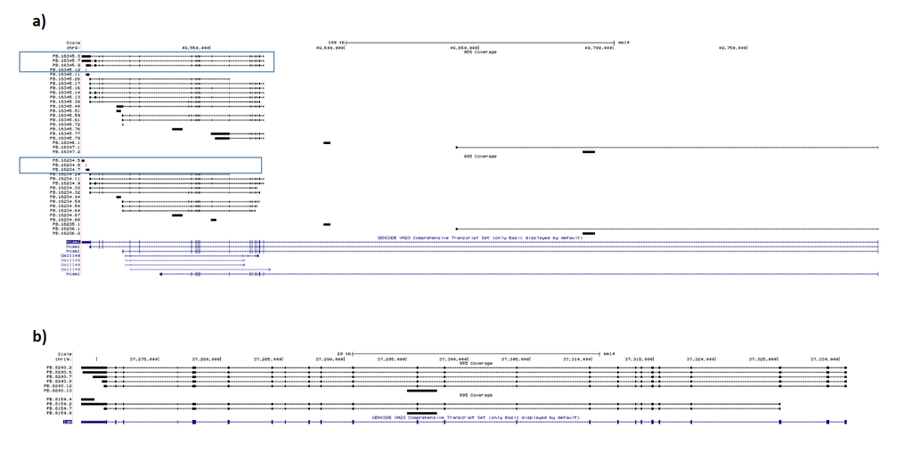

### Sqanti Filter

#### Overlap

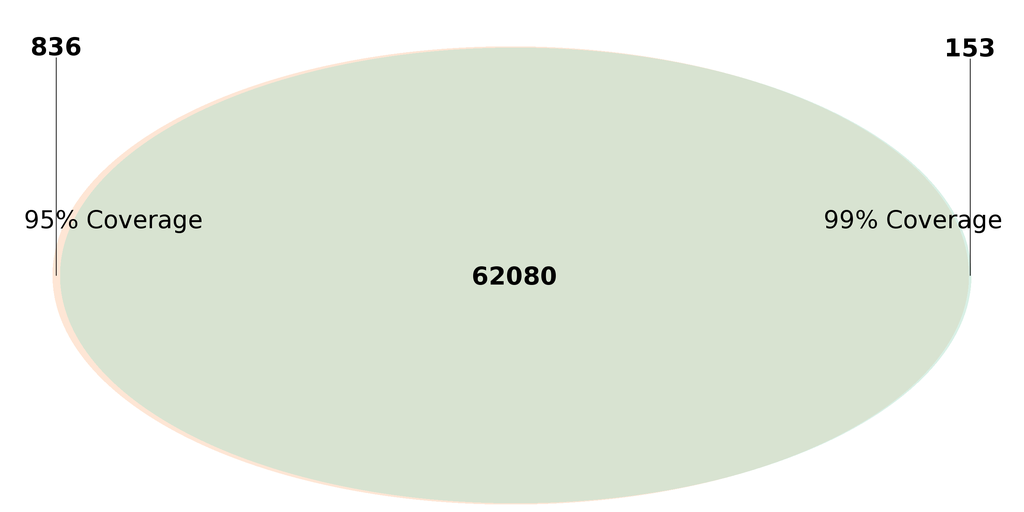

```r
grid.draw(venn_diagram_plot_twocircles(c99$sq_fil$gtf_coordinates,c95$sq_fil$gtf_coordinates,"99% Coverage","95% Coverage"))
```

### Post TAMA

#### Overlap

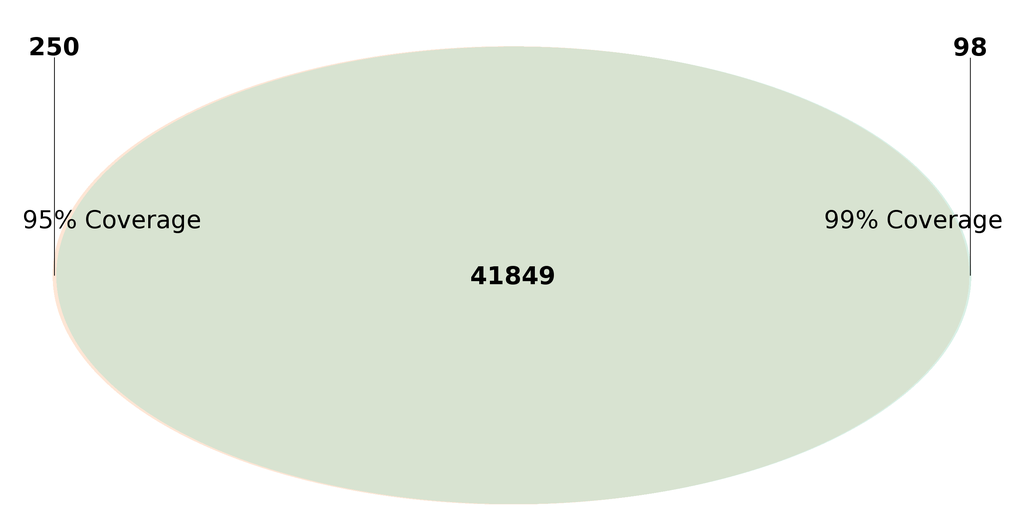

```r
grid.draw(venn_diagram_plot_twocircles(c99$sq_tama$gtf_coordinates,c95$sq_tama$gtf_coordinates,"99% Coverage","95% Coverage"))
```

#### 99% Coverage

##### Unique Isoforms

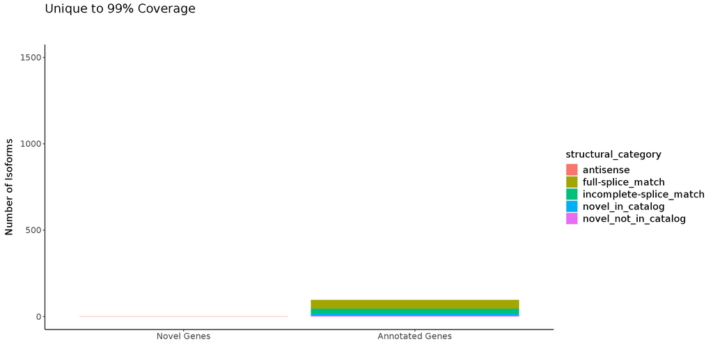

```r
# in 99% but not in 95%
c99$sq_tama %>% filter(gtf_coordinates %in% setdiff(c99$sq_tama $gtf_coordinates,c95$sq_tama $gtf_coordinates)) %>%
  group_by(structural_category,novelGene) %>% tally() %>%
  ggplot(., aes(fill = structural_category, y = n, x = novelGene)) + geom_bar(stat = "identity") +
  mytheme + labs(y = "Number of Isoforms", x = "", title = "Unique to 99% Coverage\n\n") + ylim(0,1500)
```

##### Genes - Num of Unique Isoforms

```r
datatable(c99$sq_tama %>% filter(gtf_coordinates %in% setdiff(c99$sq_tama$gtf_coordinates,c95$sq_tama$gtf_coordinates)) %>% group_by(associated_gene) %>% tally() %>% arrange(desc(n)), caption = "Genes with isoforms present in 99% but not in 95% coverage")
```

|  | associated_gene | n |
| --- | --- | --- |
| 1 | Ank2 | 2 |
| 2 | Dmwd | 2 |
| 3 | Exog | 2 |
| 4 | Inpp4b | 2 |
| 5 | Ncam1 | 2 |
| 6 | Nrxn1 | 2 |
| 7 | Rps2 | 2 |
| 8 | 1810037I17Rik | 1 |
| 9 | 3000002C10Rik | 1 |
| 10 | 4833415N18Rik | 1 |

[output cut: 81 more lines]

```r
#c99$sq_tama %>% filter(gtf_coordinates %in% setdiff(c99$sq_tama$gtf_coordinates,c95$sq_tama$gtf_coordinates)) %>% filter(associated_gene %in% targeted_genes)
```

#### 95% Coverage

##### Unique Isoforms

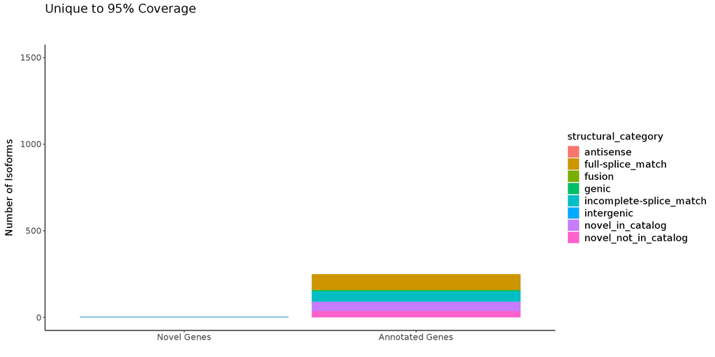

```r
# in 95% but not in 99%
c95$sq_tama %>% filter(gtf_coordinates %in% setdiff(c95$sq_tama $gtf_coordinates,c99$sq_tama $gtf_coordinates)) %>%
  group_by(structural_category,novelGene) %>% tally() %>%
  ggplot(., aes(fill = structural_category, y = n, x = novelGene)) + geom_bar(stat = "identity") +
  mytheme + labs(y = "Number of Isoforms", x = "", title = "Unique to 95% Coverage\n\n") + ylim(0,1500)
```

##### Genes - Num of Unique Isoforms

```r
datatable(c95$sq_tama %>% filter(gtf_coordinates %in% setdiff(c95$sq_tama$gtf_coordinates,c99$sq_tama$gtf_coordinates)) %>% group_by(associated_gene) %>% tally() %>% arrange(desc(n)), caption = "Genes with isoforms present in 95% but not in 99% coverage")
```

|  | associated_gene | n |
| --- | --- | --- |
| 1 | Ncam1 | 6 |
| 2 | Ank2 | 5 |
| 3 | Cadm1 | 5 |
| 4 | Selenow | 4 |
| 5 | A730017L22Rik | 3 |
| 6 | March1 | 3 |
| 7 | Rps2 | 3 |
| 8 | Atg4c | 2 |
| 9 | Dmwd | 2 |
| 10 | Exog | 2 |

[output cut: 214 more lines]

```r
# check for difference in any of the targeted genes
#c95$sq_tama %>% filter(gtf_coordinates %in% setdiff(c95$sq_tama$gtf_coordinates,c99$sq_tama$gtf_coordinates)) %>% filter(associated_gene %in% targeted_genes)
```

##### Isoforms unique to coverage-95% dataset

**Figure 1: Isoforms detected in after applying TAMA filtering of partial transcripts to SQANTI-filtered dataset**  
UCSC genome browser track of isoforms annotated to **a)** *Ncam1* gene and **b)** *Cadm1* gene after applying TAMA’s filtering (tama_remove_fragment_models.py). The same dataset was collapsed with *Cupcake* using either using coverage threshold of 99% (default) or 95% (determined experimentally using ERCCs).

TAMA filtering removed redundant 5’ partial transcripts in both datasets. However, there are evidently some isoforms (incomplete-splice match) that are in the coverage-95% dataset and not in the coverage-99% dataset.

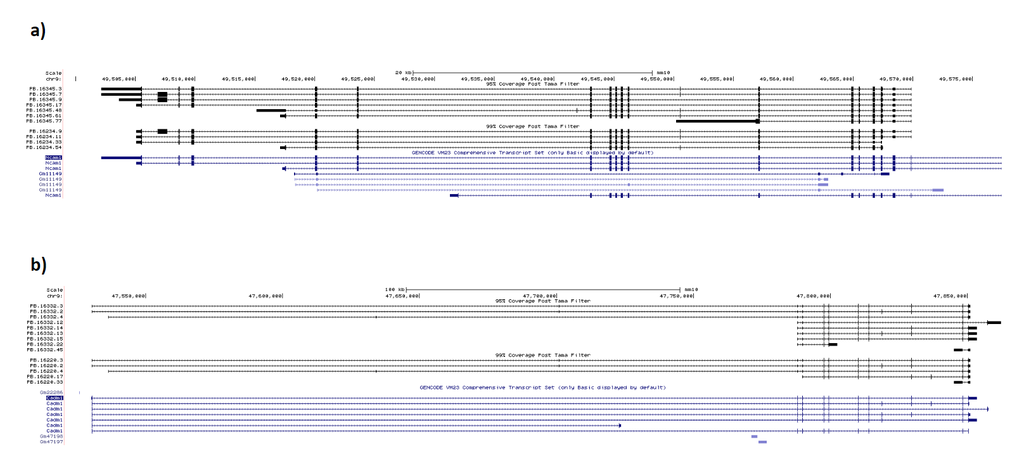